# Project: Communicate Data Findings

## Introduction

> This notebook was made in order to highlight the skills I gained throughout Udacity's Data Analyst NanoDegree, and the content presented here does not relate to any 'real-world' assessment, instead, the whole work is just for educ ational purposes.

## The Data

> I've chosen some of the Udacity's recomended datasets, which is the `Ford GoBike System`.

```python
# Importing libraries
import numpy as np
import pandas as pd
import matplotlib.pyplot as plt
import seaborn as sns
import zipfile
import sklearn.cluster as skl

%matplotlib inline
```

```python
# Reading the data
df = pd.read_csv('201902-fordgobike-tripdata.csv')
```

```python
#Inspect
print(df.shape)
df.head()
```

```
(183412, 16)
```

|  | duration_sec | start_time | end_time | start_station_id | start_station_name | start_station_latitude | start_station_longitude | end_station_id | end_station_name | end_station_latitude | end_station_longitude | bike_id | user_type | member_birth_year | member_gender | bike_share_for_all_trip |
| --- | --- | --- | --- | --- | --- | --- | --- | --- | --- | --- | --- | --- | --- | --- | --- | --- |
| 0 | 52185 | 2019-02-28 17:32:10.1450 | 2019-03-01 08:01:55.9750 | 21.0 | Montgomery St BART Station (Market St at 2nd St) | 37.789625 | -122.400811 | 13.0 | Commercial St at Montgomery St | 37.794231 | -122.402923 | 4902 | Customer | 1984.0 | Male | No |
| 1 | 42521 | 2019-02-28 18:53:21.7890 | 2019-03-01 06:42:03.0560 | 23.0 | The Embarcadero at Steuart St | 37.791464 | -122.391034 | 81.0 | Berry St at 4th St | 37.775880 | -122.393170 | 2535 | Customer | NaN | NaN | No |
| 2 | 61854 | 2019-02-28 12:13:13.2180 | 2019-03-01 05:24:08.1460 | 86.0 | Market St at Dolores St | 37.769305 | -122.426826 | 3.0 | Powell St BART Station (Market St at 4th St) | 37.786375 | -122.404904 | 5905 | Customer | 1972.0 | Male | No |
| 3 | 36490 | 2019-02-28 17:54:26.0100 | 2019-03-01 04:02:36.8420 | 375.0 | Grove St at Masonic Ave | 37.774836 | -122.446546 | 70.0 | Central Ave at Fell St | 37.773311 | -122.444293 | 6638 | Subscriber | 1989.0 | Other | No |
| 4 | 1585 | 2019-02-28 23:54:18.5490 | 2019-03-01 00:20:44.0740 | 7.0 | Frank H Ogawa Plaza | 37.804562 | -122.271738 | 222.0 | 10th Ave at E 15th St | 37.792714 | -122.248780 | 4898 | Subscriber | 1974.0 | Male | Yes |

## Data Assessing

> As the Dataset was provided by Udacity, I'll now assess its quality

```python
df.info()
```

```
<class 'pandas.core.frame.DataFrame'>
RangeIndex: 183412 entries, 0 to 183411
Data columns (total 16 columns):
duration_sec               183412 non-null int64
start_time                 183412 non-null object
end_time                   183412 non-null object
start_station_id           183215 non-null float64
start_station_name         183215 non-null object
start_station_latitude     183412 non-null float64
start_station_longitude    183412 non-null float64
end_station_id             183215 non-null float64
end_station_name           183215 non-null object
end_station_latitude       183412 non-null float64
end_station_longitude      183412 non-null float64
bike_id                    183412 non-null int64
user_type                  183412 non-null object
member_birth_year          175147 non-null float64
member_gender              175147 non-null object
bike_share_for_all_trip    183412 non-null object
dtypes: float64(7), int64(2), object(7)
memory usage: 22.4+ MB
```

It seems that we have some problems with missing data, and also that some columns have the worng datatype, for example, the `start_time`, `end_time`, the `IDs` and the `member_birth_year`.

```python
df[df.start_station_id.isnull()].head(10)
```

|  | duration_sec | start_time | end_time | start_station_id | start_station_name | start_station_latitude | start_station_longitude | end_station_id | end_station_name | end_station_latitude | end_station_longitude | bike_id | user_type | member_birth_year | member_gender | bike_share_for_all_trip |
| --- | --- | --- | --- | --- | --- | --- | --- | --- | --- | --- | --- | --- | --- | --- | --- | --- |
| 475 | 1709 | 2019-02-28 20:55:53.9320 | 2019-02-28 21:24:23.7380 | NaN | NaN | 37.40 | -121.94 | NaN | NaN | 37.40 | -121.93 | 4211 | Customer | 1991.0 | Female | No |
| 1733 | 1272 | 2019-02-28 18:32:34.2730 | 2019-02-28 18:53:46.7270 | NaN | NaN | 37.40 | -121.94 | NaN | NaN | 37.41 | -121.96 | 4174 | Subscriber | 1980.0 | Male | No |
| 3625 | 142 | 2019-02-28 17:10:46.5290 | 2019-02-28 17:13:09.4310 | NaN | NaN | 37.41 | -121.95 | NaN | NaN | 37.41 | -121.96 | 4283 | Subscriber | 1988.0 | Male | No |
| 4070 | 585 | 2019-02-28 16:28:45.9340 | 2019-02-28 16:38:31.3320 | NaN | NaN | 37.39 | -121.93 | NaN | NaN | 37.40 | -121.92 | 4089 | Subscriber | 1984.0 | Male | Yes |
| 5654 | 509 | 2019-02-28 12:30:17.1310 | 2019-02-28 12:38:46.3290 | NaN | NaN | 37.40 | -121.92 | NaN | NaN | 37.39 | -121.93 | 4089 | Subscriber | 1984.0 | Male | Yes |
| 6214 | 1334 | 2019-02-28 10:32:47.9300 | 2019-02-28 10:55:02.0280 | NaN | NaN | 37.40 | -121.93 | NaN | NaN | 37.38 | -121.93 | 4150 | Customer | 1990.0 | Male | No |
| 8499 | 240 | 2019-02-28 08:23:07.0920 | 2019-02-28 08:27:07.2890 | NaN | NaN | 37.41 | -121.96 | NaN | NaN | 37.41 | -121.95 | 4283 | Subscriber | 1988.0 | Male | No |
| 8783 | 883 | 2019-02-28 07:58:07.3720 | 2019-02-28 08:12:51.2760 | NaN | NaN | 37.41 | -121.96 | NaN | NaN | 37.40 | -121.94 | 4211 | Subscriber | 1980.0 | Male | No |
| 10967 | 116 | 2019-02-27 19:25:57.0360 | 2019-02-27 19:27:54.0260 | NaN | NaN | 37.41 | -121.95 | NaN | NaN | 37.41 | -121.95 | 4283 | Subscriber | 1988.0 | Male | No |
| 11071 | 828 | 2019-02-27 19:03:14.6380 | 2019-02-27 19:17:03.4340 | NaN | NaN | 37.40 | -121.94 | NaN | NaN | 37.41 | -121.96 | 4091 | Subscriber | 1980.0 | Male | No |

As we can see, the rows with missing data seems to have similar coordinates

```python
df[df.start_station_id.isnull()].start_station_latitude.value_counts()
```

```
37.41    101
37.40     63
37.42     21
37.39     11
37.38      1
Name: start_station_latitude, dtype: int64
```

```python
df[df.start_station_id.isnull()].start_station_longitude.value_counts()
```

```
-121.94    57
-121.96    46
-121.93    46
-121.95    37
-121.92    10
-121.98     1
Name: start_station_longitude, dtype: int64
```

And here we can see the most frequent coordinates, we can see how they compare with the other coordinates, just to try to see some data issue

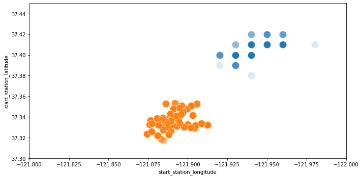

```python
axes, figure = plt.subplots(figsize = (10,5))
sns.scatterplot(data = df[df.start_station_id.isnull()], x = "start_station_longitude", y = "start_station_latitude", alpha = 0.15, s = 200)
sns.scatterplot(data = df.dropna(subset=["start_station_id"]), x = "start_station_longitude", y = "start_station_latitude", alpha = 0.15, s = 200)
plt.xlim(-121.8,-122)
plt.ylim(37.3,37.45)
plt.tight_layout()
```

In the plot above, the blue dots represent the NaN stations, and we can see that they are entirelly out of the range of the other stations.

```python
start_station_id_list = list(df.start_station_id.drop_duplicates().dropna().astype("int"))
start_station_id_list.sort()

end_station_id_list = list(df.end_station_id.drop_duplicates().dropna().astype("int"))
end_station_id_list.sort()

start_station_id_list == end_station_id_list
```

```
True
```

The True statement here proves that.

```python
df_station_names = df[["end_station_id", "end_station_name", "end_station_latitude", "end_station_longitude"]].copy()

df_station_names.rename(columns={"end_station_id": "id",
                                 "end_station_name": "station_name",
                                 "end_station_latitude": "station_latitude",
                                 "end_station_longitude": "station_longitude"}, inplace = True)

df_station_names.drop_duplicates(inplace = True)
df_station_names.dropna(inplace = True)
df_station_names.sort_values("id", inplace = True)
df_station_names.reset_index(inplace = True, drop = True)
```

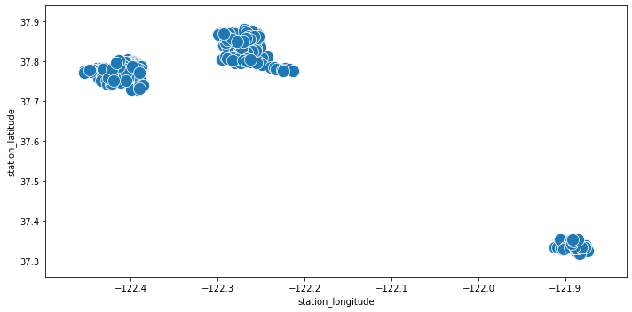

```python
axes, figure = plt.subplots(figsize = (10,5))
sns.scatterplot(data = df_station_names, x = "station_longitude", y = "station_latitude", s = 200)

plt.tight_layout()
```

Inspecting this simple scatter plot, we can see that the data have three clear clusters, and this is due to the locations where the data is represented, which by reading the documentation we can see that the clusters refer to three specific locations: `San Francisco`, `East Bay Area` and `San José`.

```python
# Analyzing station's id
df_station_names.drop_duplicates(subset = ["id", "station_latitude", "station_longitude"]).id.value_counts().head(25)
```

```
389.0    1
121.0    1
123.0    1
124.0    1
125.0    1
126.0    1
127.0    1
129.0    1
130.0    1
131.0    1
132.0    1
133.0    1
134.0    1
136.0    1
137.0    1
138.0    1
139.0    1
140.0    1
141.0    1
122.0    1
120.0    1
189.0    1
119.0    1
99.0     1
100.0    1
Name: id, dtype: int64
```

```python
# Analyzing numeric variables
df.describe().round(2)
```

|  | duration_sec | start_station_id | start_station_latitude | start_station_longitude | end_station_id | end_station_latitude | end_station_longitude | bike_id | member_birth_year |
| --- | --- | --- | --- | --- | --- | --- | --- | --- | --- |
| count | 183412.00 | 183215.00 | 183412.00 | 183412.00 | 183215.00 | 183412.00 | 183412.00 | 183412.00 | 175147.00 |
| mean | 726.08 | 138.59 | 37.77 | -122.35 | 136.25 | 37.77 | -122.35 | 4472.91 | 1984.81 |
| std | 1794.39 | 111.78 | 0.10 | 0.12 | 111.52 | 0.10 | 0.12 | 1664.38 | 10.12 |
| min | 61.00 | 3.00 | 37.32 | -122.45 | 3.00 | 37.32 | -122.45 | 11.00 | 1878.00 |
| 25% | 325.00 | 47.00 | 37.77 | -122.41 | 44.00 | 37.77 | -122.41 | 3777.00 | 1980.00 |
| 50% | 514.00 | 104.00 | 37.78 | -122.40 | 100.00 | 37.78 | -122.40 | 4958.00 | 1987.00 |
| 75% | 796.00 | 239.00 | 37.80 | -122.29 | 235.00 | 37.80 | -122.29 | 5502.00 | 1992.00 |
| max | 85444.00 | 398.00 | 37.88 | -121.87 | 398.00 | 37.88 | -121.87 | 6645.00 | 2001.00 |

```python
df.query("duration_sec == 85444.00")
```

|  | duration_sec | start_time | end_time | start_station_id | start_station_name | start_station_latitude | start_station_longitude | end_station_id | end_station_name | end_station_latitude | end_station_longitude | bike_id | user_type | member_birth_year | member_gender | bike_share_for_all_trip |
| --- | --- | --- | --- | --- | --- | --- | --- | --- | --- | --- | --- | --- | --- | --- | --- | --- |
| 101361 | 85444 | 2019-02-13 17:59:55.1240 | 2019-02-14 17:43:59.9540 | 5.0 | Powell St BART Station (Market St at 5th St) | 37.783899 | -122.408445 | 98.0 | Valencia St at 16th St | 37.765052 | -122.421866 | 6168 | Subscriber | NaN | NaN | No |

```python
df.query("duration_sec > 80000")
```

|  | duration_sec | start_time | end_time | start_station_id | start_station_name | start_station_latitude | start_station_longitude | end_station_id | end_station_name | end_station_latitude | end_station_longitude | bike_id | user_type | member_birth_year | member_gender | bike_share_for_all_trip |
| --- | --- | --- | --- | --- | --- | --- | --- | --- | --- | --- | --- | --- | --- | --- | --- | --- |
| 5203 | 83195 | 2019-02-27 14:47:23.1810 | 2019-02-28 13:53:58.4330 | 243.0 | Bancroft Way at College Ave | 37.869360 | -122.254337 | 248.0 | Telegraph Ave at Ashby Ave | 37.855956 | -122.259795 | 5781 | Subscriber | 1962.0 | Female | Yes |
| 8631 | 81549 | 2019-02-27 09:41:38.5520 | 2019-02-28 08:20:48.3860 | 138.0 | Jersey St at Church St | 37.750900 | -122.427411 | 140.0 | Cesar Chavez St at Dolores St | 37.747858 | -122.424986 | 2266 | Subscriber | 1963.0 | Female | No |
| 85465 | 84548 | 2019-02-16 15:48:25.0290 | 2019-02-17 15:17:33.0800 | 3.0 | Powell St BART Station (Market St at 4th St) | 37.786375 | -122.404904 | 368.0 | Myrtle St at Polk St | 37.785434 | -122.419622 | 6301 | Subscriber | 1981.0 | Male | No |
| 95750 | 82512 | 2019-02-14 13:56:21.7280 | 2019-02-15 12:51:34.3150 | 368.0 | Myrtle St at Polk St | 37.785434 | -122.419622 | 44.0 | Civic Center/UN Plaza BART Station (Market St ... | 37.781074 | -122.411738 | 6152 | Customer | 1998.0 | Other | No |
| 101361 | 85444 | 2019-02-13 17:59:55.1240 | 2019-02-14 17:43:59.9540 | 5.0 | Powell St BART Station (Market St at 5th St) | 37.783899 | -122.408445 | 98.0 | Valencia St at 16th St | 37.765052 | -122.421866 | 6168 | Subscriber | NaN | NaN | No |
| 112435 | 83407 | 2019-02-11 16:25:33.0690 | 2019-02-12 15:35:40.9560 | 77.0 | 11th St at Natoma St | 37.773507 | -122.416040 | 344.0 | 16th St Depot | 37.766349 | -122.396292 | 1842 | Customer | 1988.0 | Male | No |
| 127999 | 83519 | 2019-02-09 15:16:17.5370 | 2019-02-10 14:28:17.2700 | 72.0 | Page St at Scott St | 37.772406 | -122.435650 | 43.0 | San Francisco Public Library (Grove St at Hyde... | 37.778768 | -122.415929 | 5561 | Customer | 1990.0 | Male | No |
| 153705 | 83772 | 2019-02-05 12:44:54.2860 | 2019-02-06 12:01:06.6310 | 78.0 | Folsom St at 9th St | 37.773717 | -122.411647 | 345.0 | Hubbell St at 16th St | 37.766483 | -122.398279 | 3405 | Customer | NaN | NaN | No |
| 173365 | 82385 | 2019-02-02 13:07:43.0360 | 2019-02-03 12:00:48.1750 | 377.0 | Fell St at Stanyan St | 37.771917 | -122.453704 | 377.0 | Fell St at Stanyan St | 37.771917 | -122.453704 | 2933 | Customer | NaN | NaN | No |
| 176987 | 80891 | 2019-02-01 11:05:18.9760 | 2019-02-02 09:33:30.1690 | 44.0 | Civic Center/UN Plaza BART Station (Market St ... | 37.781074 | -122.411738 | 55.0 | Webster St at Grove St | 37.777053 | -122.429558 | 3133 | Customer | NaN | NaN | No |

As there are some more trips that have taken more than 80000 seconds, we can let them here for further investigation.

```python
# Analyzing missing values in the birth_year column
df[df.member_birth_year.isnull()].head()
```

|  | duration_sec | start_time | end_time | start_station_id | start_station_name | start_station_latitude | start_station_longitude | end_station_id | end_station_name | end_station_latitude | end_station_longitude | bike_id | user_type | member_birth_year | member_gender | bike_share_for_all_trip |
| --- | --- | --- | --- | --- | --- | --- | --- | --- | --- | --- | --- | --- | --- | --- | --- | --- |
| 1 | 42521 | 2019-02-28 18:53:21.7890 | 2019-03-01 06:42:03.0560 | 23.0 | The Embarcadero at Steuart St | 37.791464 | -122.391034 | 81.0 | Berry St at 4th St | 37.775880 | -122.393170 | 2535 | Customer | NaN | NaN | No |
| 13 | 915 | 2019-02-28 23:49:06.0620 | 2019-03-01 00:04:21.8670 | 252.0 | Channing Way at Shattuck Ave | 37.865847 | -122.267443 | 244.0 | Shattuck Ave at Hearst Ave | 37.873676 | -122.268487 | 5101 | Subscriber | NaN | NaN | No |
| 28 | 650 | 2019-02-28 23:43:27.5030 | 2019-02-28 23:54:18.4510 | 258.0 | University Ave at Oxford St | 37.872355 | -122.266447 | 263.0 | Channing Way at San Pablo Ave | 37.862827 | -122.290230 | 4784 | Customer | NaN | NaN | No |
| 53 | 3418 | 2019-02-28 22:41:16.3620 | 2019-02-28 23:38:14.3630 | 11.0 | Davis St at Jackson St | 37.797280 | -122.398436 | 11.0 | Davis St at Jackson St | 37.797280 | -122.398436 | 319 | Customer | NaN | NaN | No |
| 65 | 926 | 2019-02-28 23:17:05.8530 | 2019-02-28 23:32:32.6820 | 13.0 | Commercial St at Montgomery St | 37.794231 | -122.402923 | 81.0 | Berry St at 4th St | 37.775880 | -122.393170 | 2951 | Subscriber | NaN | NaN | No |

It's totally possible that the ones that don't have their birth year here, were not required to do, or even if required, did not want to provide it.

### Assessing Summary

Some issues that I need to fix in the data:

**Quality**

- station_id, station_name, member_birth_year and member_gender columns all have missing values
- start_time and end_time are in the wrong datatype
- start_station_id, end_station_id, member_birth_year and bike_id are in the wrong datatype

**Tideness**

- There are no tidiness issues

## Data Cleaning

#### Define

> station_id, station_name, member_birth_year and member_gender columns all have missing values

#### Clean

```python
# Drop station id
df.dropna(subset = ["start_station_id"], inplace = True)
```

```python
#fill up the missing values in gender and birth
df.member_birth_year.fillna(0, inplace = True)
df.member_gender.fillna("Not Defined", inplace = True)
```

#### Test

```python
df.info()
```

```
<class 'pandas.core.frame.DataFrame'>
Int64Index: 183215 entries, 0 to 183411
Data columns (total 16 columns):
duration_sec               183215 non-null int64
start_time                 183215 non-null object
end_time                   183215 non-null object
start_station_id           183215 non-null float64
start_station_name         183215 non-null object
start_station_latitude     183215 non-null float64
start_station_longitude    183215 non-null float64
end_station_id             183215 non-null float64
end_station_name           183215 non-null object
end_station_latitude       183215 non-null float64
end_station_longitude      183215 non-null float64
bike_id                    183215 non-null int64
user_type                  183215 non-null object
member_birth_year          183215 non-null float64
member_gender              183215 non-null object
bike_share_for_all_trip    183215 non-null object
dtypes: float64(7), int64(2), object(7)
memory usage: 23.8+ MB
```

#### Define

> start_time and end_time are in the wrong datatype

#### Clean

```python
for col in ["start_time", "end_time"]:
    df[col] = pd.to_datetime(df[col])
```

#### Test

```python
df.info()
```

```
<class 'pandas.core.frame.DataFrame'>
Int64Index: 183215 entries, 0 to 183411
Data columns (total 16 columns):
duration_sec               183215 non-null int64
start_time                 183215 non-null datetime64[ns]
end_time                   183215 non-null datetime64[ns]
start_station_id           183215 non-null float64
start_station_name         183215 non-null object
start_station_latitude     183215 non-null float64
start_station_longitude    183215 non-null float64
end_station_id             183215 non-null float64
end_station_name           183215 non-null object
end_station_latitude       183215 non-null float64
end_station_longitude      183215 non-null float64
bike_id                    183215 non-null int64
user_type                  183215 non-null object
member_birth_year          183215 non-null float64
member_gender              183215 non-null object
bike_share_for_all_trip    183215 non-null object
dtypes: datetime64[ns](2), float64(7), int64(2), object(5)
memory usage: 23.8+ MB
```

#### Define

> start_station_id, end_station_id, member_birth_year and bike_id are in the wrong datatype

#### Clean

```python
for col in ["start_station_id", "end_station_id"]:
    df[col] = df[col].astype("int")

for col in ["start_station_id", "end_station_id", "member_birth_year", "bike_id"]:
    df[col] = df[col].astype("str")
```

#### Test

```python
df.info()
```

```
<class 'pandas.core.frame.DataFrame'>
Int64Index: 183215 entries, 0 to 183411
Data columns (total 16 columns):
duration_sec               183215 non-null int64
start_time                 183215 non-null datetime64[ns]
end_time                   183215 non-null datetime64[ns]
start_station_id           183215 non-null object
start_station_name         183215 non-null object
start_station_latitude     183215 non-null float64
start_station_longitude    183215 non-null float64
end_station_id             183215 non-null object
end_station_name           183215 non-null object
end_station_latitude       183215 non-null float64
end_station_longitude      183215 non-null float64
bike_id                    183215 non-null object
user_type                  183215 non-null object
member_birth_year          183215 non-null object
member_gender              183215 non-null object
bike_share_for_all_trip    183215 non-null object
dtypes: datetime64[ns](2), float64(4), int64(1), object(9)
memory usage: 23.8+ MB
```

##### Note

> There's a thing that I can improve, and it's the way the station's ids are structured, so we can create a new id in order to better deal with this.

Since this is not an important issue, I did not included as a data issue.

```python
def get_new_id(col):

    #when the row is not in id_data - append it
    if col[0] not in id_data:
        id_data[col[0]] = [col[1], col[2], col[3], f"{col[0]}_0"]
        return id_data[col[0]][3]

    #if the row exists in id_data, then check if the coordinates change, if yes - calculate the distance and increase the id and replace the \
    #saved coordinates in id_data with the new ones, if not, then just return the saved id
    elif col[0] in id_data:
        if id_data[col[0]][1] != col[2] or id_data[col[0]][2] != col[3]:
            coords_1 = (id_data[col[0]][1], id_data[col[0]][2])
            coords_2 = (col[2], col[3])

            if geopy.distance.distance(coords_1, coords_2).m > 100:
                new_ind = str(col[0]) + "_" + str(int(id_data[col[0]][3][-1])+1)
                id_data[col[0]][3] = new_ind
                id_data[col[0]][1] = col[2]
                id_data[col[0]][2] = col[3]

                return new_ind
            else:
                return id_data[col[0]][3]

        else:
            return id_data[col[0]][3]

    else:
        return "Error"
```

```python
id_data = {}
df["start_station_id_new"] = df[["start_station_id", "start_station_name", "start_station_latitude", "start_station_longitude"]].apply(get_new_id, axis = 1)
```

```python
id_data = {}
df["end_station_id_new"] = df[["end_station_id", "end_station_name", "end_station_latitude", "end_station_longitude"]].apply(get_new_id, axis = 1)
```

```python
df_station_names.head()
```

|  | id | station_name | station_latitude | station_longitude |
| --- | --- | --- | --- | --- |
| 0 | 3.0 | Powell St BART Station (Market St at 4th St) | 37.786375 | -122.404904 |
| 1 | 4.0 | Cyril Magnin St at Ellis St | 37.785881 | -122.408915 |
| 2 | 5.0 | Powell St BART Station (Market St at 5th St) | 37.783899 | -122.408445 |
| 3 | 6.0 | The Embarcadero at Sansome St | 37.804770 | -122.403234 |
| 4 | 7.0 | Frank H Ogawa Plaza | 37.804562 | -122.271738 |

```python
df_station_names = df[["start_time", "start_station_id", "start_station_name", "start_station_latitude", "start_station_longitude"]].copy()
df_station_names.sort_values("start_time", inplace = True)
df_station_names.drop("start_time", axis = 1, inplace = True)
df_station_names.rename(columns={"start_station_id": "id",
                                 "start_station_name": "station_name",
                                 "start_station_latitude": "station_latitude",
                                 "start_station_longitude": "station_longitude"}, inplace = True)

df_station_names.drop_duplicates(inplace = True)
df_station_names.dropna(inplace = True)
id_data = {}
df_station_names["new_id"] = df_station_names[["id", "station_name", "station_latitude", "station_longitude"]].apply(get_new_id, axis = 1)
df_station_names.sort_values("id", inplace = True)
df_station_names.reset_index(inplace = True, drop = True)
```

```python
df_station_names.head()
```

|  | id | station_name | station_latitude | station_longitude | new_id |
| --- | --- | --- | --- | --- | --- |
| 0 | 10 | Washington St at Kearny St | 37.795393 | -122.404770 | 10_0 |
| 1 | 100 | Bryant St at 15th St | 37.767100 | -122.410662 | 100_0 |
| 2 | 101 | 15th St at Potrero Ave | 37.767079 | -122.407359 | 101_0 |
| 3 | 102 | Irwin St at 8th St | 37.766883 | -122.399579 | 102_0 |
| 4 | 104 | 4th St at 16th St | 37.767045 | -122.390833 | 104_0 |

```python
#export the station names to csv
df_station_names.to_csv("df_station_names.csv", index = False)
```

```python
#export the cleaned csv
df.to_csv("df_clean.csv", index = False)
```

## Data Visualizing

### Exploratory Data Visualization

Let's visualize the data

From here, I have two DFs:

- df
- df_station_names

```python
df.info()
```

```
<class 'pandas.core.frame.DataFrame'>
Int64Index: 183215 entries, 0 to 183411
Data columns (total 18 columns):
duration_sec               183215 non-null int64
start_time                 183215 non-null datetime64[ns]
end_time                   183215 non-null datetime64[ns]
start_station_id           183215 non-null object
start_station_name         183215 non-null object
start_station_latitude     183215 non-null float64
start_station_longitude    183215 non-null float64
end_station_id             183215 non-null object
end_station_name           183215 non-null object
end_station_latitude       183215 non-null float64
end_station_longitude      183215 non-null float64
bike_id                    183215 non-null object
user_type                  183215 non-null object
member_birth_year          183215 non-null object
member_gender              183215 non-null object
bike_share_for_all_trip    183215 non-null object
start_station_id_new       183215 non-null object
end_station_id_new         183215 non-null object
dtypes: datetime64[ns](2), float64(4), int64(1), object(11)
memory usage: 26.6+ MB
```

```python
print(df.shape)
df.head()
```

```
(183215, 18)
```

|  | duration_sec | start_time | end_time | start_station_id | start_station_name | start_station_latitude | start_station_longitude | end_station_id | end_station_name | end_station_latitude | end_station_longitude | bike_id | user_type | member_birth_year | member_gender | bike_share_for_all_trip | start_station_id_new | end_station_id_new |
| --- | --- | --- | --- | --- | --- | --- | --- | --- | --- | --- | --- | --- | --- | --- | --- | --- | --- | --- |
| 0 | 52185 | 2019-02-28 17:32:10.145 | 2019-03-01 08:01:55.975 | 21 | Montgomery St BART Station (Market St at 2nd St) | 37.789625 | -122.400811 | 13 | Commercial St at Montgomery St | 37.794231 | -122.402923 | 4902 | Customer | 1984.0 | Male | No | 21_0 | 13_0 |
| 1 | 42521 | 2019-02-28 18:53:21.789 | 2019-03-01 06:42:03.056 | 23 | The Embarcadero at Steuart St | 37.791464 | -122.391034 | 81 | Berry St at 4th St | 37.775880 | -122.393170 | 2535 | Customer | 0.0 | Not Defined | No | 23_0 | 81_0 |
| 2 | 61854 | 2019-02-28 12:13:13.218 | 2019-03-01 05:24:08.146 | 86 | Market St at Dolores St | 37.769305 | -122.426826 | 3 | Powell St BART Station (Market St at 4th St) | 37.786375 | -122.404904 | 5905 | Customer | 1972.0 | Male | No | 86_0 | 3_0 |
| 3 | 36490 | 2019-02-28 17:54:26.010 | 2019-03-01 04:02:36.842 | 375 | Grove St at Masonic Ave | 37.774836 | -122.446546 | 70 | Central Ave at Fell St | 37.773311 | -122.444293 | 6638 | Subscriber | 1989.0 | Other | No | 375_0 | 70_0 |
| 4 | 1585 | 2019-02-28 23:54:18.549 | 2019-03-01 00:20:44.074 | 7 | Frank H Ogawa Plaza | 37.804562 | -122.271738 | 222 | 10th Ave at E 15th St | 37.792714 | -122.248780 | 4898 | Subscriber | 1974.0 | Male | Yes | 7_0 | 222_0 |

```python
df_station_names.info()
```

```
<class 'pandas.core.frame.DataFrame'>
RangeIndex: 329 entries, 0 to 328
Data columns (total 5 columns):
id                   329 non-null object
station_name         329 non-null object
station_latitude     329 non-null float64
station_longitude    329 non-null float64
new_id               329 non-null object
dtypes: float64(2), object(3)
memory usage: 13.0+ KB
```

```python
print(df_station_names.shape)
df_station_names.head()
```

```
(329, 5)
```

|  | id | station_name | station_latitude | station_longitude | new_id |
| --- | --- | --- | --- | --- | --- |
| 0 | 10 | Washington St at Kearny St | 37.795393 | -122.404770 | 10_0 |
| 1 | 100 | Bryant St at 15th St | 37.767100 | -122.410662 | 100_0 |
| 2 | 101 | 15th St at Potrero Ave | 37.767079 | -122.407359 | 101_0 |
| 3 | 102 | Irwin St at 8th St | 37.766883 | -122.399579 | 102_0 |
| 4 | 104 | 4th St at 16th St | 37.767045 | -122.390833 | 104_0 |

##### Note

> One this that we clearly saw in the cleaning process, was that the data was divides into three clusters, so one thing that we can do here, is classify them accordingly

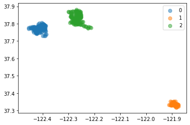

```python
#https://datatofish.com/k-means-clustering-python/

kmeans = skl.KMeans(n_clusters=3).fit(df_station_names[["station_longitude", "station_latitude"]])

df_station_names["label"] = kmeans.labels_

for x in set(list(df_station_names.label)):

    df_plot_cluster = df_station_names.query(f"label == {x}")

    plt.scatter(df_plot_cluster['station_longitude'], df_plot_cluster["station_latitude"], s=50, alpha=0.5, label = x);

plt.legend();
```

##### Note

> As we can see, the data in this dataset refer to three specific locations, San Francisco, East Bay and San José, so it's easy for us to map them accordingly

```python
mapping = {0: "San Francisco", 1: "San José", 2: "East Bay"}
```

```python
df_station_names["label_name"] = df_station_names["label"].map(mapping)
```

```python
df_station_names.head()
```

|  | id | station_name | station_latitude | station_longitude | new_id | label | label_name |
| --- | --- | --- | --- | --- | --- | --- | --- |
| 0 | 10 | Washington St at Kearny St | 37.795393 | -122.404770 | 10_0 | 0 | San Francisco |
| 1 | 100 | Bryant St at 15th St | 37.767100 | -122.410662 | 100_0 | 0 | San Francisco |
| 2 | 101 | 15th St at Potrero Ave | 37.767079 | -122.407359 | 101_0 | 0 | San Francisco |
| 3 | 102 | Irwin St at 8th St | 37.766883 | -122.399579 | 102_0 | 0 | San Francisco |
| 4 | 104 | 4th St at 16th St | 37.767045 | -122.390833 | 104_0 | 0 | San Francisco |

```python
df_station_names.label_name.value_counts()
```

```
San Francisco    156
East Bay         127
San José          46
Name: label_name, dtype: int64
```

```python
df_station_names.info()
```

```
<class 'pandas.core.frame.DataFrame'>
RangeIndex: 329 entries, 0 to 328
Data columns (total 7 columns):
id                   329 non-null object
station_name         329 non-null object
station_latitude     329 non-null float64
station_longitude    329 non-null float64
new_id               329 non-null object
label                329 non-null int32
label_name           329 non-null object
dtypes: float64(2), int32(1), object(4)
memory usage: 16.8+ KB
```

```python
df[df.duplicated(subset = ["start_time", "end_time"], keep = False)]
```

|  | duration_sec | start_time | end_time | start_station_id | start_station_name | start_station_latitude | start_station_longitude | end_station_id | end_station_name | end_station_latitude | end_station_longitude | bike_id | user_type | member_birth_year | member_gender | bike_share_for_all_trip | start_station_id_new | end_station_id_new |
| --- | --- | --- | --- | --- | --- | --- | --- | --- | --- | --- | --- | --- | --- | --- | --- | --- | --- | --- |

```python
# Now we can merge them, so we can better use the data
df = df.merge(df_station_names[["new_id", "label"]], left_on = "start_station_id_new", right_on = "new_id", how = "outer")
```

```python
df.info()
```

```
<class 'pandas.core.frame.DataFrame'>
Int64Index: 183215 entries, 0 to 183214
Data columns (total 20 columns):
duration_sec               183215 non-null int64
start_time                 183215 non-null datetime64[ns]
end_time                   183215 non-null datetime64[ns]
start_station_id           183215 non-null object
start_station_name         183215 non-null object
start_station_latitude     183215 non-null float64
start_station_longitude    183215 non-null float64
end_station_id             183215 non-null object
end_station_name           183215 non-null object
end_station_latitude       183215 non-null float64
end_station_longitude      183215 non-null float64
bike_id                    183215 non-null object
user_type                  183215 non-null object
member_birth_year          183215 non-null object
member_gender              183215 non-null object
bike_share_for_all_trip    183215 non-null object
start_station_id_new       183215 non-null object
end_station_id_new         183215 non-null object
new_id                     183215 non-null object
label                      183215 non-null int32
dtypes: datetime64[ns](2), float64(4), int32(1), int64(1), object(12)
memory usage: 28.7+ MB
```

```python
df.query("start_station_id == '205'").drop_duplicates("start_station_id_new")[["start_station_id", "start_station_name", "start_station_latitude", "start_station_longitude", "start_station_id_new", "label"]]
```

|  | start_station_id | start_station_name | start_station_latitude | start_station_longitude | start_station_id_new | label |
| --- | --- | --- | --- | --- | --- | --- |
| 181224 | 205 | Miles Ave at Cavour St | 37.8388 | -122.258732 | 205_0 | 2 |

```python
df["label_name"] = df["label"].map(mapping)
```

```python
df.label_name.value_counts()
```

```
San Francisco    133708
East Bay          41434
San José           8073
Name: label_name, dtype: int64
```

##### Note

> From here, I will extract some information that I think can be relevant for our analysis, for example, we can separate information in order to get a more accurate usage pattern, and we can also calculate the users' ages.

```python
df["age"] = df["member_birth_year"].apply(lambda x: 2019 - float(x))
```

```python
df['month_year'] = pd.to_datetime(df["start_time"]).dt.to_period('M')
```

```python
df['day_month_year'] = pd.to_datetime(df["start_time"]).dt.to_period('D')
```

```python
df["dayofweek"] = df["start_time"].apply(lambda x: x.dayofweek)
```

```python
df["start_hr"] = df["start_time"].apply(lambda x: x.hour)
df["end_hr"] = df["end_time"].apply(lambda x: x.hour)
```

```python
df_age = df.query("age != 2018 and age < 100").copy()
```

```python
# Creating age bins in order to better visualize the data
bins = [x for x in range(10,101, 10)]
df_age["age_bins"] = pd.cut(df_age.age, bins = bins, precision = 0, include_lowest=False)
```

```python
df_age[["age", "age_bins"]].head()
```

|  | age | age_bins |
| --- | --- | --- |
| 0 | 35.0 | (30, 40] |
| 1 | 33.0 | (30, 40] |
| 2 | 33.0 | (30, 40] |
| 3 | 27.0 | (20, 30] |
| 4 | 61.0 | (60, 70] |

```python
df.head()
```

|  | duration_sec | start_time | end_time | start_station_id | start_station_name | start_station_latitude | start_station_longitude | end_station_id | end_station_name | end_station_latitude | ... | end_station_id_new | new_id | label | label_name | age | month_year | day_month_year | dayofweek | start_hr | end_hr |
| --- | --- | --- | --- | --- | --- | --- | --- | --- | --- | --- | --- | --- | --- | --- | --- | --- | --- | --- | --- | --- | --- |
| 0 | 52185 | 2019-02-28 17:32:10.145 | 2019-03-01 08:01:55.975 | 21 | Montgomery St BART Station (Market St at 2nd St) | 37.789625 | -122.400811 | 13 | Commercial St at Montgomery St | 37.794231 | ... | 13_0 | 21_0 | 0 | San Francisco | 35.0 | 2019-02 | 2019-02-28 | 3 | 17 | 8 |
| 1 | 239 | 2019-02-28 23:28:42.709 | 2019-02-28 23:32:41.769 | 21 | Montgomery St BART Station (Market St at 2nd St) | 37.789625 | -122.400811 | 343 | Bryant St at 2nd St | 37.783172 | ... | 343_0 | 21_0 | 0 | San Francisco | 33.0 | 2019-02 | 2019-02-28 | 3 | 23 | 23 |
| 2 | 430 | 2019-02-28 21:17:07.919 | 2019-02-28 21:24:18.403 | 21 | Montgomery St BART Station (Market St at 2nd St) | 37.789625 | -122.400811 | 16 | Steuart St at Market St | 37.794130 | ... | 16_0 | 21_0 | 0 | San Francisco | 33.0 | 2019-02 | 2019-02-28 | 3 | 21 | 21 |
| 3 | 753 | 2019-02-28 21:10:17.662 | 2019-02-28 21:22:51.155 | 21 | Montgomery St BART Station (Market St at 2nd St) | 37.789625 | -122.400811 | 76 | McCoppin St at Valencia St | 37.771662 | ... | 76_0 | 21_0 | 0 | San Francisco | 27.0 | 2019-02 | 2019-02-28 | 3 | 21 | 21 |
| 4 | 352 | 2019-02-28 21:14:29.897 | 2019-02-28 21:20:22.700 | 21 | Montgomery St BART Station (Market St at 2nd St) | 37.789625 | -122.400811 | 27 | Beale St at Harrison St | 37.788059 | ... | 27_0 | 21_0 | 0 | San Francisco | 61.0 | 2019-02 | 2019-02-28 | 3 | 21 | 21 |

5 rows × 27 columns

```python
df.info()
```

```
<class 'pandas.core.frame.DataFrame'>
Int64Index: 183215 entries, 0 to 183214
Data columns (total 27 columns):
duration_sec               183215 non-null int64
start_time                 183215 non-null datetime64[ns]
end_time                   183215 non-null datetime64[ns]
start_station_id           183215 non-null object
start_station_name         183215 non-null object
start_station_latitude     183215 non-null float64
start_station_longitude    183215 non-null float64
end_station_id             183215 non-null object
end_station_name           183215 non-null object
end_station_latitude       183215 non-null float64
end_station_longitude      183215 non-null float64
bike_id                    183215 non-null object
user_type                  183215 non-null object
member_birth_year          183215 non-null object
member_gender              183215 non-null object
bike_share_for_all_trip    183215 non-null object
start_station_id_new       183215 non-null object
end_station_id_new         183215 non-null object
new_id                     183215 non-null object
label                      183215 non-null int32
label_name                 183215 non-null object
age                        183215 non-null float64
month_year                 183215 non-null period[M]
day_month_year             183215 non-null period[D]
dayofweek                  183215 non-null int64
start_hr                   183215 non-null int64
end_hr                     183215 non-null int64
dtypes: datetime64[ns](2), float64(5), int32(1), int64(4), object(13), period[D](1), period[M](1)
memory usage: 38.4+ MB
```

Now, we can begin the exploration properly

### Univariate Exploration

To begin, I will analyze the distribution of some variables that I think are important

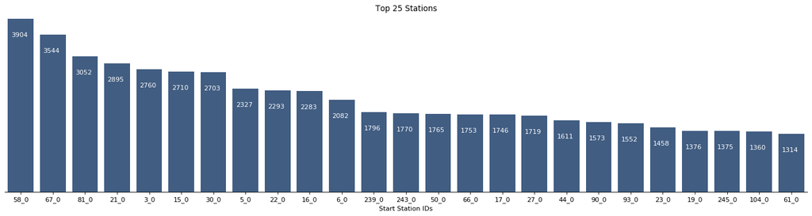

```python
#https://codeyarns.com/2015/06/29/how-to-hide-axis-of-plot-in-matplotlib/

value_ct = df.start_station_id_new.value_counts().iloc[:25]

fig, ax = plt.subplots(figsize = (22,5), dpi = 80)
color = sns.color_palette("viridis")[1]
sns.countplot(x = "start_station_id_new", data = df, order=value_ct.index, color = color);

plt.ylim(0,4000)

cur_axes = plt.gca()
cur_axes.axes.get_yaxis().set_visible(False)

sns.despine(fig, left = True)

for p in ax.patches:
    ax.annotate('{:.0f}'.format(p.get_height()), (p.get_x()+0.1, p.get_height()-400), color = "white")

plt.title("Top 25 Stations");
plt.xlabel("Start Station IDs");
```

Here we can see what are the most used stations, and with a little more work, we can see the name of each station

```python
for x in value_ct.index:
    print(x + " - " + str(df.query(f"start_station_id_new == '{x}'").start_station_name.drop_duplicates().get_values()))
```

```
58_0 - ['Market St at 10th St']
67_0 - ['San Francisco Caltrain Station 2  (Townsend St at 4th St)']
81_0 - ['Berry St at 4th St']
21_0 - ['Montgomery St BART Station (Market St at 2nd St)']
3_0 - ['Powell St BART Station (Market St at 4th St)']
15_0 - ['San Francisco Ferry Building (Harry Bridges Plaza)']
30_0 - ['San Francisco Caltrain (Townsend St at 4th St)']
5_0 - ['Powell St BART Station (Market St at 5th St)']
22_0 - ['Howard St at Beale St']
16_0 - ['Steuart St at Market St']
6_0 - ['The Embarcadero at Sansome St']
239_0 - ['Bancroft Way at Telegraph Ave']
243_0 - ['Bancroft Way at College Ave']
50_0 - ['2nd St at Townsend St']
66_0 - ['3rd St at Townsend St']
17_0 - ['Embarcadero BART Station (Beale St at Market St)']
27_0 - ['Beale St at Harrison St']
44_0 - ['Civic Center/UN Plaza BART Station (Market St at McAllister St)']
90_0 - ['Townsend St at 7th St']
93_0 - ['4th St at Mission Bay Blvd S']
23_0 - ['The Embarcadero at Steuart St']
19_0 - ['Post St at Kearny St']
245_0 - ['Downtown Berkeley BART']
104_0 - ['4th St at 16th St']
61_0 - ['Howard St at 8th St']
```

##### Note

> One thing that the transformation in the data allowed us to do here, is to separate our analysis into places, since it's really straightforwar to do, we can now see the most used stations for each specific location.

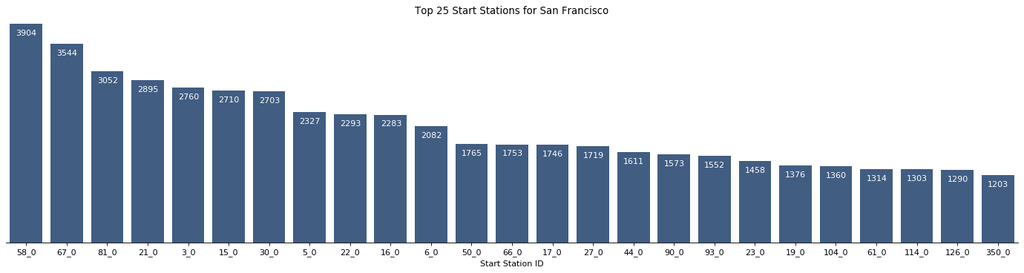

```python
# San Francisco
#https://codeyarns.com/2015/06/29/how-to-hide-axis-of-plot-in-matplotlib/

df_new = df.query("label == 0").copy()

value_ct = df_new.start_station_id_new.value_counts().iloc[:25]

fig, ax = plt.subplots(figsize = (22,5), dpi = 80)
color = sns.color_palette("viridis")[1]
sns.countplot(x = "start_station_id_new", data = df_new, order=value_ct.index, color = color);

plt.ylim(0,4000)

cur_axes = plt.gca()
#cur_axes.axes.get_xaxis().set_visible(False)
cur_axes.axes.get_yaxis().set_visible(False)

sns.despine(fig, left = True)

for p in ax.patches:
    ax.annotate('{:.0f}'.format(p.get_height()), (p.get_x()+0.15, p.get_height()-200), color = "white")

plt.title("Top 25 Start Stations for San Francisco");
plt.xlabel("Start Station ID");
```

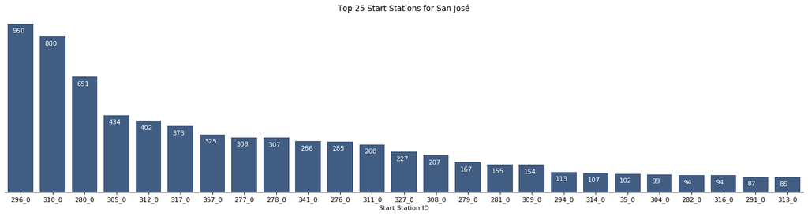

```python
#https://codeyarns.com/2015/06/29/how-to-hide-axis-of-plot-in-matplotlib/

df_new = df.query("label == 1").copy()

value_ct = df_new.start_station_id_new.value_counts().iloc[:25]

fig, ax = plt.subplots(figsize = (22,5), dpi = 80)
color = sns.color_palette("viridis")[1]
sns.countplot(x = "start_station_id_new", data = df_new, order=value_ct.index, color = color);

plt.ylim(0,1000)

cur_axes = plt.gca()
#cur_axes.axes.get_xaxis().set_visible(False)
cur_axes.axes.get_yaxis().set_visible(False)

sns.despine(fig, left = True)

for p in ax.patches:
    ax.annotate('{:.0f}'.format(p.get_height()), (p.get_x()+0.15, p.get_height()-50), color = "white")

plt.title("Top 25 Start Stations for San José");
plt.xlabel("Start Station ID");
```

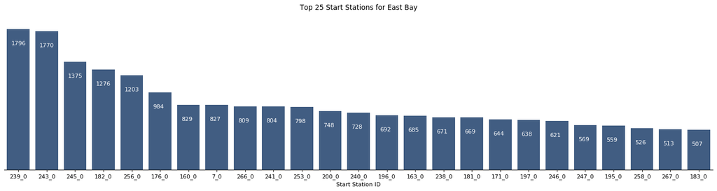

```python
#https://codeyarns.com/2015/06/29/how-to-hide-axis-of-plot-in-matplotlib/

df_new = df.query("label == 2").copy()

value_ct = df_new.start_station_id_new.value_counts().iloc[:25]

fig, ax = plt.subplots(figsize = (22,5), dpi = 80)
color = sns.color_palette("viridis")[1]
sns.countplot(x = "start_station_id_new", data = df_new, order=value_ct.index, color = color);

plt.ylim(0,2000)

cur_axes = plt.gca()
#cur_axes.axes.get_xaxis().set_visible(False)
cur_axes.axes.get_yaxis().set_visible(False)

sns.despine(fig, left = True)

for p in ax.patches:
    ax.annotate('{:.0f}'.format(p.get_height()), (p.get_x()+0.15, p.get_height()-200), color = "white")

plt.title("Top 25 Start Stations for East Bay");
plt.xlabel("Start Station ID");
```

##### Note

> As we could see here, just from the independent analysis, the San Francisco Area is by far, the most used area, and there we have the first 11 stations by number of users.

Now, let's analyze other variables

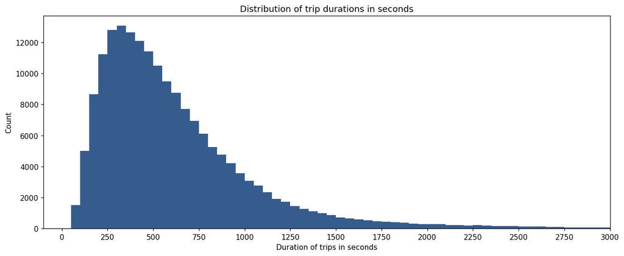

```python
# The duration seems to be a very importante variable here
bin_size = 50
bins = np.arange(0,df.duration_sec.max()+bin_size,bin_size)

fig, axes = plt.subplots(figsize = (12,5), dpi = 110)

plt.hist(df.duration_sec, bins = bins, color= color);
plt.xticks(ticks = [x for x in range(0,7000,250)])
plt.xlim(-100,3000);
plt.xlabel('Duration of trips in seconds');
plt.ylabel('Count');
plt.title('Distribution of trip durations in seconds');
plt.tight_layout()
```

I've limited this graph to consider only 3 thousand second in limit, just in order to zoom where the most amount of data lies in our distribution.

##### Note

> And here we can see that most trips lasts between 250 and 550 seconds.

And we can also see the duration for each of the regions that we assigned for the data.

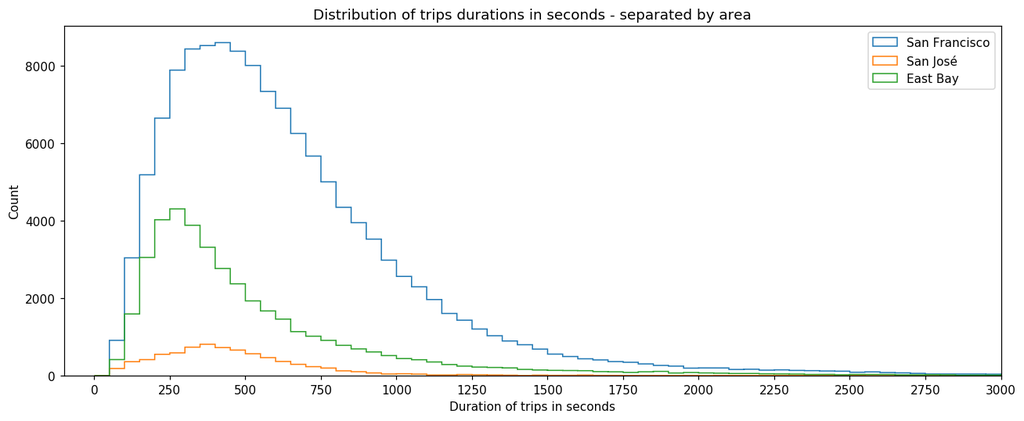

```python
fig, axes = plt.subplots(figsize = (12,5), dpi = 110)
for x in mapping.values():
    df_new = df.query(f"label_name == '{x}'")

    bin_size = 50
    bins = np.arange(0,df_new.duration_sec.max()+bin_size,bin_size)

    plt.hist(df_new.duration_sec, bins = bins, label = x, histtype='step');

plt.xticks(ticks = [x for x in range(0,7000,250)])
plt.legend()
plt.xlim(-100,3000);
plt.xlabel('Duration of trips in seconds');
plt.ylabel('Count')
plt.title('Distribution of trips durations in seconds - separated by area');
plt.tight_layout()
```

##### Note

> Here we have a Bivariate plot, but I'll let it here just in order to facilitate the comparison with the Univariate plot above it.

> Although the distribution for San José has a more aproximately normal shape, just a little skewed to the right, we can see that the distributions are similar, and also we can see the usage of each region.

We can now, analyze the users-related data

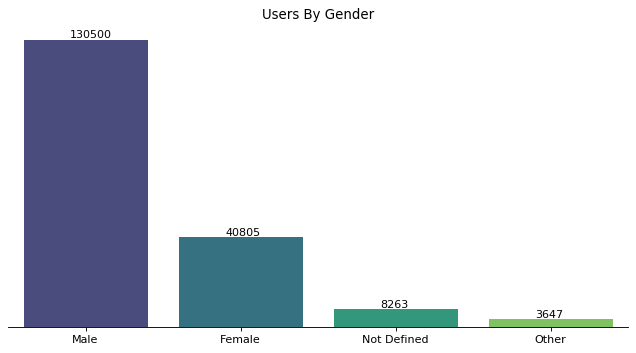

```python
fig, ax = plt.subplots(figsize = (10,5), dpi = 80)
sns.countplot(x = "member_gender", data = df,  order=df.member_gender.value_counts().index, palette='viridis');

cur_axes = plt.gca()
cur_axes.axes.get_yaxis().set_visible(False)
sns.despine(fig, left = True)

for p in ax.patches:
    ax.annotate('{:.0f}'.format(p.get_height()), (p.get_x()+0.3, p.get_height()+750))

plt.title("Users By Gender");
plt.xlabel("");
```

##### Note

> We can see that the number of men that uses the service is hugely greater than the other classifications.

##### Note

We can also see how the time in which every trip starts is distributed:

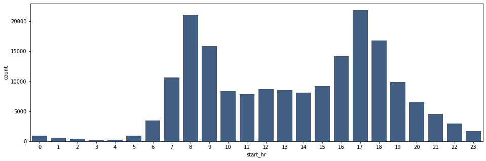

```python
fig, ax = plt.subplots(figsize = (16,5))

sns.countplot(x = "start_hr", data = df, color=color, ax = ax);
```

##### Note

> From here, we can think that usually, people use the service to commute, since the two modes of this data is around the time where people normally commute.

### Bivariate Exploration

> Although some analysis above already produced some bivariate plots, The goal here is to see if can get any relationship in the data.

One question that I made to myself when analyzing the data was if there's a relationship between the duration of the trip and the hour in which each trip starts.

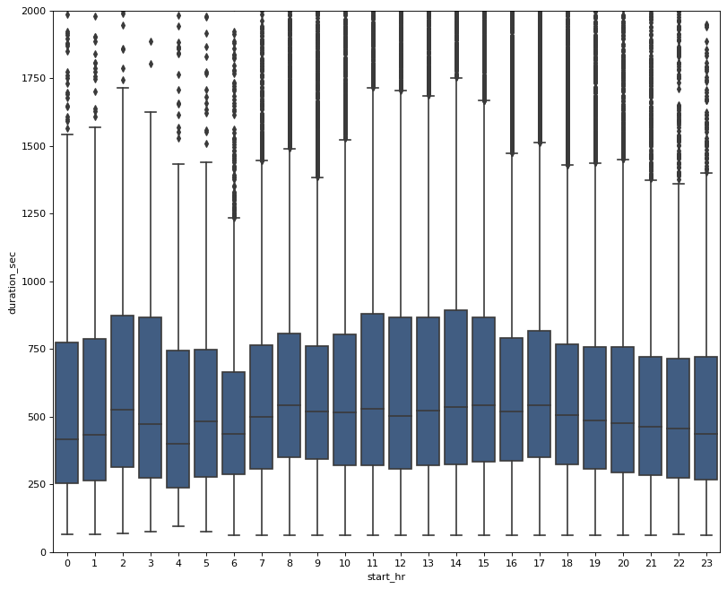

```python
#https://stackoverflow.com/questions/4700614/how-to-put-the-legend-out-of-the-plot

fig, ax = plt.subplots(figsize = (15,10), dpi = 80)
sns.boxplot(x = "start_hr", y = "duration_sec", data = df, color = color)

box = ax.get_position()
ax.set_position([box.x0, box.y0, box.width * 0.8, box.height])
plt.ylim(0, 2000);
```

##### Note

> Here we can see that, although the most used times are around 8AM and 5PM (17), the duration does not follow the same direction, and here we can imagine that the users that take trips out of these periods tend to do for recreational purposes.

We can see information about which user we're dealing with, if the specific user is either a customer or a subscriber.

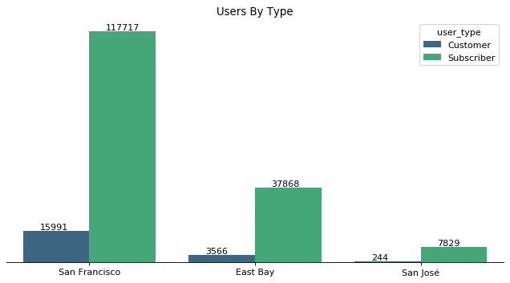

```python
value_ct = df.label_name.value_counts().iloc[:31]

fig, ax = plt.subplots(figsize = (10,5), dpi = 80)
sns.countplot(x = "label_name", data = df, order=value_ct.index, palette = "viridis", hue = "user_type");

cur_axes = plt.gca()
cur_axes.axes.get_yaxis().set_visible(False)
sns.despine(fig, left = True)

for p in ax.patches:
    ax.annotate('{:.0f}'.format(p.get_height()), (p.get_x()+0.1, p.get_height()+750))

plt.title("Users By Type");
plt.xlabel("");
```

### Multivariate Exploration

> To finish, we can see if the data in question produces some effect in the number of users if we consider different areas and gender.

We can now use some techniques in order to better view how the duration varies regarding the day of the week and the area in which we're examining.

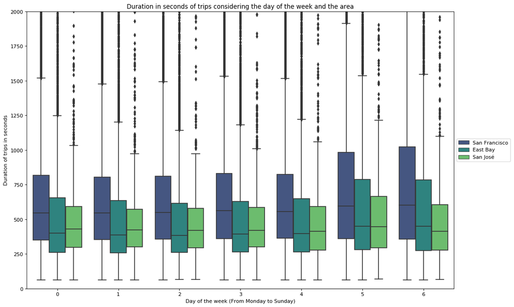

```python
#https://stackoverflow.com/questions/4700614/how-to-put-the-legend-out-of-the-plot

fig, ax = plt.subplots(figsize = (15,10), dpi = 80)
sns.boxplot(x = "dayofweek", y = "duration_sec", data = df, palette = "viridis", hue = "label_name")

box = ax.get_position()
ax.legend(loc='center left', bbox_to_anchor=(1, 0.5))
plt.ylim(0, 2000);
plt.title('Duration in seconds of trips considering the day of the week and the area');
plt.xlabel('Day of the week (From Monday to Sunday)');
plt.ylabel('Duration of trips in seconds');
```

##### Note

> We can see from the plot above that, although the median usage of the service is almost the same throughout the week, we have a more spread usage, considering the quartiles, on the weekend, which can easily be explained because people on weekeds tend to do more recreational trips.

We can now analyze some information regarding the users.

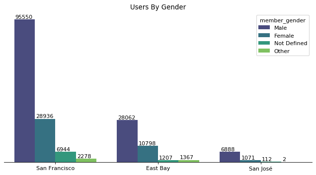

```python
fig, ax = plt.subplots(figsize = (10,5), dpi = 80)
sns.countplot(x = "label_name", data = df,  order=df.label_name.value_counts().index, palette = "viridis", hue = "member_gender");

cur_axes = plt.gca()
cur_axes.axes.get_yaxis().set_visible(False)
sns.despine(fig, left = True)

for p in ax.patches:
    ax.annotate('{:.0f}'.format(p.get_height()), (p.get_x()+0.01, p.get_height()+750))

plt.title("Users By Gender");
plt.xlabel("");
```

##### Note

> Here we can see that the number of users follows a pattern, and we have, for ecery region in this data, more men than wonem, and if we look at San Francisco, where we have the most part of our data, we can see that the gap only increased when compared to the other regions.

```python
#export the final csv file
df.to_csv("df_final.csv", index = False)
```